# Examine IRR

Rex Macey

January 24, 2016

```r
library(stringr)
library(plyr)
library(lubridate)
library(randomForest)
library(reshape2)
library(formattable)
setwd(Sys.getenv("LENDINGCLUB_DIR"))  # this gets the LENDINGCLUB_DIR variable defined in the .rProfile file
df<-readRDS("LoanStatsAll.rds")
df2<-df # used for all loans
```

(Modified 1/24/2016 to add weighted means. Weighting is by funding amount.) The number of loans (rows of data) is 756,887.

We need to consider completed loans. It’s not fair to include a loan initiated 1 year ago that defaulted. Doing so would include bad loans from recent periods but not loans that turn out to be good. We filter for loans that are have a term of 3 years initiated at least 3 years ago or a term of 5 years initiated at least 5 years ago.

```r
max_issue_d<-max(df$issue_d,na.rm=TRUE)
idx<- (df2$issue_d < (max_issue_d - 3) & df$term == " 36 months") | (df2$issue_d < (max_issue_d - 5) & df$term == " 60 months")
df<-df[idx,]
```

Now we are down to a much smaller number (56,269) of loans (about 7.4% of the entire data set). Does it seem correct that LC has initiated 10x loans since these were complete.

The loans have terms of either 3 or 5 years. Below we see that 3 Year loans dominate completed loans

```r
tbl<-rbind(summary(df$term),round(100*summary(df$term)/nrow(df),0))[,2:3]
rownames(tbl)<-c("Count","Pct")
tbl
```

```
##        36 months  60 months
## Count      54743       1526
## Pct           97          3
```

It appears LC is making many more 5 year loans now based on the table below which considers all loans.

```r
tbl<-rbind(summary(df2$term),round(100*summary(df2$term)/nrow(df2),0))[,2:3]
rownames(tbl)<-c("Count","Pct")
tbl
```

```
##        36 months  60 months
## Count     532317     224561
## Pct           70         30
```

So a model built on completed loans only has 1,526 five-year loans. One may want to limit the model to three year loans.

Now we turn to the status of the loans as classified by LC. First we list the status and then show how many “completed” loans fall in to each category.

```r
status_levels<-levels(df$loan_status)
status_levels
```

```
##  [1] ""
##  [2] "Charged Off"
##  [3] "Current"
##  [4] "Default"
##  [5] "Does not meet the credit policy. Status:Charged Off"
##  [6] "Does not meet the credit policy. Status:Current"
##  [7] "Does not meet the credit policy. Status:Fully Paid"
##  [8] "Fully Paid"
##  [9] "In Grace Period"
## [10] "Late (16-30 days)"
## [11] "Late (31-120 days)"
```

```r
summary(df$loan_status)
```

```
##
##                                                   0
##                                         Charged Off
##                                                6795
##                                             Current
##                                                   0
##                                             Default
##                                                   1
## Does not meet the credit policy. Status:Charged Off
##                                                 698
##     Does not meet the credit policy. Status:Current
##                                                   0
##  Does not meet the credit policy. Status:Fully Paid
##                                                1889
##                                          Fully Paid
##                                               46882
##                                     In Grace Period
##                                                   0
##                                   Late (16-30 days)
##                                                   0
##                                  Late (31-120 days)
##                                                   4
```

It’s odd that a a handful of the loans we thought would be completed are either late (4) or in default (1). To be careful we only use loans with the following codes

```r
complete_status<-status_levels[c(2,5,7,8)]
complete_status
```

```
## [1] "Charged Off"
## [2] "Does not meet the credit policy. Status:Charged Off"
## [3] "Does not meet the credit policy. Status:Fully Paid"
## [4] "Fully Paid"
```

```r
idx<-df$loan_status %in% complete_status
df<-df[idx,]
loan.status.dist<-data.frame(table(df$loan_status)) #distribution of by loan status
loan.status.dist$PctTotal<-round(100*loan.status.dist$Freq/sum(loan.status.dist$Freq),1)
loan.status.dist<-loan.status.dist[loan.status.dist$Freq>0,]
loan.status.dist
```

```
##                                                  Var1  Freq PctTotal
## 2                                         Charged Off  6795     12.1
## 5 Does not meet the credit policy. Status:Charged Off   698      1.2
## 7  Does not meet the credit policy. Status:Fully Paid  1889      3.4
## 8                                          Fully Paid 46882     83.3
```

```r
# Calculate or lookup IRR
if (FALSE) {
    source("IRR.R")
    df$irr<-NA
    for(i in 1:nrow(df)){
        df$irr[i]<-IRR(df$total_pymnt[i],df$total_rec_late_fee[i],df$collection_recovery_fee[i],df$installment[i],df$funded_amnt[i],df$issue_d[i])
    }
    saveRDS(df,file=paste0(getwd(),"/","irr.rds"))
} else {
    df<-readRDS(paste0(getwd(),"/","irr.rds"))
}
summary(df$irr) # negative skew
```

```
##     Min.  1st Qu.   Median     Mean  3rd Qu.     Max.
## -0.99990  0.05762  0.09258  0.02151  0.13130  0.27870
```

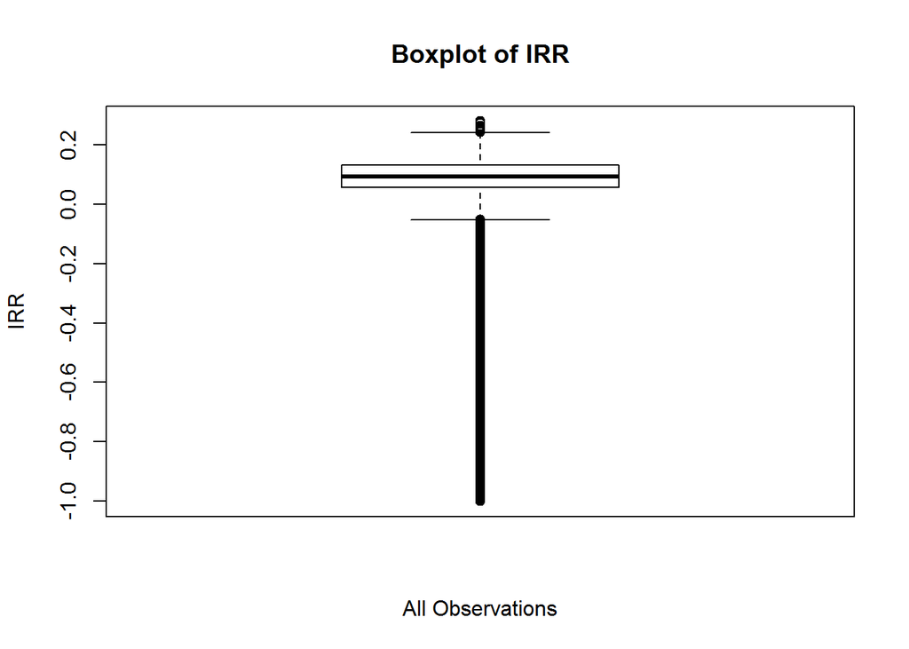

```r
boxplot(df$irr,main="Boxplot of IRR",ylab="IRR",xlab="All Observations")
```

```r
# IRR by loan status
irr<-df$irr
meanbystatus <- ddply(df, .(loan_status),summarise,
                      MeanIRR=round(100*mean(irr,na.rm=T),1),
                      WtMeanIRR=round(100*weighted.mean(irr,funded_amnt,na.rm=TRUE),1),
                      MedianIRR=round(100*median(irr,na.rm=T),1),
                      Count=length(irr),
                      FreqPct=round(100*length(irr)/length(df[,1]),1))
print(meanbystatus)
```

```
##                                           loan_status MeanIRR WtMeanIRR
## 1                                         Charged Off   -50.9     -50.4
## 2 Does not meet the credit policy. Status:Charged Off   -58.8     -60.2
## 3  Does not meet the credit policy. Status:Fully Paid    12.7      13.0
## 4                                          Fully Paid    10.3      10.7
##   MedianIRR Count FreqPct
## 1     -51.1  6795    12.1
## 2     -66.9   698     1.2
## 3      13.5  1889     3.4
## 4      10.2 46882    83.3
```

```r
meanbygrade <- ddply(df, .(grade),summarise,
                      MeanIRR=round(100*mean(irr,na.rm=T),1),
                      WtMeanIRR=round(100*weighted.mean(irr,funded_amnt,na.rm=TRUE),1),
                      MedianIRR=round(100*median(irr,na.rm=T),1),
                      Count=length(irr),
                      FreqPct=round(100*length(irr)/length(df[,1]),1))
print(meanbygrade)
```

```
##   grade MeanIRR WtMeanIRR MedianIRR Count FreqPct
## 1     A     2.7       3.0       6.7 16462    29.3
## 2     B     2.9       3.2      10.6 18650    33.1
## 3     C     1.8       2.5      13.4 11638    20.7
## 4     D     1.1       2.2      15.1  6658    11.8
## 5     E    -0.4       1.4      15.8  2011     3.6
## 6     F    -6.3      -7.5      15.8   564     1.0
## 7     G    -5.1      -5.0      18.1   281     0.5
```

```r
meanbyyear <- ddply(df, .(year_issued),summarise,
                      MeanIRR=round(100*mean(irr,na.rm=TRUE),1),
                      WtMeanIRR=round(100*weighted.mean(irr,funded_amnt,na.rm=TRUE),1),
                      MedianIRR=round(100*median(irr,na.rm=T),1),
                      Count=length(irr),
                      FreqPct=round(100*length(irr)/length(df[,1]),1))
print(meanbyyear)
```

```
##   year_issued MeanIRR WtMeanIRR MedianIRR Count FreqPct
## 1        2007    -6.3      -9.1       9.3   603     1.1
## 2        2008    -3.2      -5.6      10.3  2393     4.3
## 3        2009     1.8       1.2      10.7  5281     9.4
## 4        2010     2.6       3.0       9.5 10679    19.0
## 5        2011     2.8       3.9       7.9 14101    25.1
## 6        2012     2.4       2.8       9.3 23207    41.2
```